# Dados de precipitação diária estimada pelo modelo regional Eta

## 1. Apresentação

A seguir são descritos os procedimentos para obtenção dos dados pertinentes às previsões de precipitação acumulada em 24 hs provenientes do modelo regional Eta, e a conversão desses em formato matricial (raster) utilizando a linguagem de programação R. As estimativas de precipitação mencionadas foram realizadas em rodadas sub sazonais e disponibilizadas para aplicação em modelagem hidrológica, conforme a demanda do grupo de pesquisa vinculado ao projeto “*Incorporação de previsões climáticas e hidrológicas na gestão da alocação de água do Rio São Francisco*”. O projeto referido é financiado pela Coordenação de Aperfeiçoamento de Pessoal de Nível Superior (CAPES) e pela Agência Nacional de Águas (ANA).

## 2. Estrutura dos dados disponibilizados

As estimativas de precipitação seguiram uma estrutura em grade regular com resolução horizontal de 20 km e compreenderam o período de 2015 a 2020. As previsões foram incluídas em arquivos compactados `.tar.gz` e disponibilizadas em [servidor FTP](http://ftp1.cptec.inpe.br/pesquisa/grpeta/subsazonal/Gustavo/Eta20km/Benedito/). Cada arquivo compactado correspondente a uma determinada data contem os seguintes arquivos em formato binário `.bin`, e os seus respectivos arquivos descritores `.ctl`:

- `ocis_Eta20km(date).bin`: *downward short wave at ground (W/m²)*;
- `prec_Eta20km(date).bin`: *total precipitation (Kg/m²/day)*;
- `pslc_Eta20km(date).bin`: *surface pressure (hPa)*;
- `tp2m_Eta20km(date).bin`: *2 metre temperature (K)*;
- `u10m_Eta20km(date).bin`: *10 metre u-wind component (m/s)*;
- `umrl_Eta20km(date).bin`: *specific humidity (kg/kg)*;
- `v10m_Eta20km(date).bin`: *10 metre v-wind component (m/s)*;

## 3. Conversão dos arquivos binários

Foi utilizado o ambiente R para a leitura dos arquivos `.bin` e posterior conversão desses em outros formatos, i.e., imagens raster com extensão `.tiff` que possibilitaram o acesso à informação (valor numérico) correspondente a cada pixel que as compuseram. A leitura dos dados binários no R foi feita a partir da função `readGradsFile` contida no pacote [readgrads](https://github.com/lhmet/readgrads?ref=https://githubhelp.com), desenvolvido para manipulação de dados oriundos do software [GrADS](http://cola.gmu.edu/grads/) (*Grid Analysis and Display System*), utilizado comumente para visualização de dados geofísicos.

Após o download e descompactação dos arquivos `.bin` e `.ctl` referentes a uma determinada data e horário de previsão, esses foram armazenados em um mesmo diretório. A partir de então, os arquivos foram importados no R e uma função específica foi criada para a conversão do formato. Uma vez que cada arquivo binário continha as 60 previsões consecutivas obtidas a partir das condições iniciais de uma determinada data, foram criados objetos `RasterStack` a partir da função descrita anteriormente contendo uma coleção de 60 objetos `RasterLayer` com a mesma extensão espacial e resolução. Além disso, a função mencionada também definiu o sistema de referência de coordenadas (SRC) dos arquivos de saída e, neste caso, foi utilizado o datum WGS 84 (*World Geodetic System 1984*), código epsg 4326. Destaca-se que, além do pacote `readgrads`, os pacotes `raster`, desenvolvido para operações com dados espaciais em formato matricial e vetorial, e `data.table`, desenvolvido para agregação de grandes conjuntos de dados, foram requisitados para a execução do procedimento mencionado.

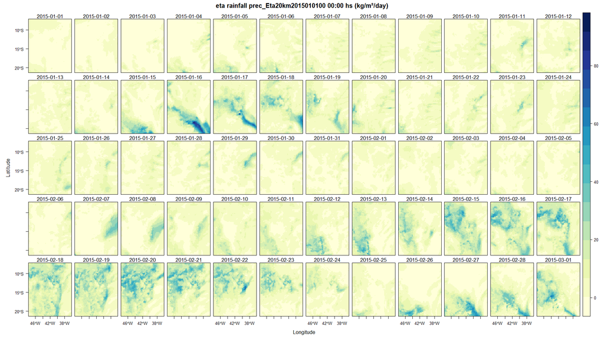

**Figura 1**. Coleção de objetos `RasterLayer` com resolução horizontal de 20 km contidas em um objeto `RasterStack` contendo as previsões de precipitação obtidas pelo modelo Eta para os 60 dias consecutivos a partir do dia 01/02015.

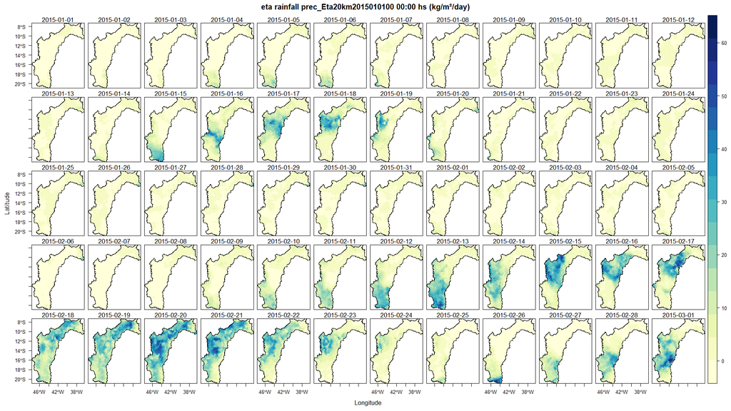

**Figura 2**. Coleção de objetos `RasterLayer` com resolução horizontal de 20 km contidas em um objeto `RasterStack` contendo as previsões de precipitação obtidas pelo modelo Eta para os 60 dias consecutivos a partir do dia 01/02015, recortadas para a extensão da bacia do Rio São Francisco.

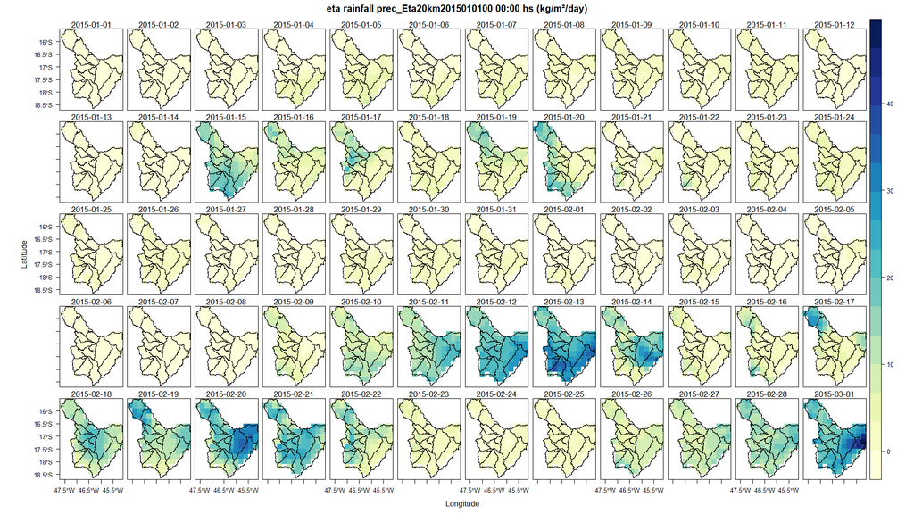

**Figura 3**. Coleção de objetos `RasterLayer` com resolução horizontal de 20 km contidas em um objeto `RasterStack` contendo as previsões de precipitação obtidas pelo modelo Eta para os 60 dias consecutivos a partir do dia 01/02015, recortadas para a extensão da bacia do Rio Paracatu.

## 4. Script

- `dset`(emsp)^prec_Eta20km2015010100.bin
- `title` File
- `undef` 1e+20
- `xdef` 59 linear -47.8 0.20
- `ydef` 71 linear -21.2 0.20
- `zdef` 1 levels 1000
- `tdef` 241 linear 00Z01Jan2015 6hr
- `vars` 1
- `prec` 1 99 TOTAL PRECIPITATION [Kg/m2/day]
- `endvars`

Obs: para execução deste script, os apenas os arquivos `.bin` e `.ctl` correspondentes a previsão de precipitação diária foram extraidos previamente do arquivo original `2015010100.tar.gz`.

## 5. Executando o script

### 5.1 Carregando as bibliotecas requeridas

```r
library(readgrads)
library(data.table)
library(raster)
```

Obs: instale o pacote `readgrads` diretamente do github utilizando o seguinte comando (requer o pacote “devtools”)

```r
library(devtools)
devtools::install_github("lhmet/readgrads")
```

### 5.2 Escrevendo a função “raster_layers” para conversão do arquivo binário

Obs: uma vez que cada arquivo `.bin` compreende 60 estimativas de precipitação a partir de uma data inicial, essa função retorna um objeto `RasterStack` contendo uma coleção de arquivos raster em formato `.tiff`, todos com a mesma extensão e resolução espacial.

```r
raster_layers <- function(dat){

  min_tstep <- min(dat$tstep)
  max_tstep <- max(dat$tstep)
  breaks <- seq(min_tstep, max_tstep, by = 4)

  ## Passo 1: criar subconjuntos (dias de previsão) com base na variável tstep do arquivo binário
  dat$group <- cut(dat$tstep, breaks)
  dat <- dat[!is.na(dat$group), ]
  ## Passo 2: calcular os valores de precipitação acumulada
  prec <- setDT(dat)[ , list(prec_sum = sum(prec * 1000)), by = list(group, x, y)]
  ## Passo 3: criar os arquivos raster e incluir o sistema de referência de coordenadas
  layer <- list()
  group <- unique(prec$group)
  j <- 1
  for (i in group){

    raster_dat <- prec[prec$group %in% i , c("x", "y", "prec_sum")]

    colnames(raster_dat)[colnames(raster_dat) == "prec_sum"] <- paste0("prec_sum_", j)
    layer[[j]] <-
      rasterFromXYZ(raster_dat,
                    res = c(0.20, 0.20),
                    crs = sp::CRS("+init=epsg:4326"))
    j <- j + 1
  }
  ## Passo 4: criar o arquivo RasterStack
  stack_prec <- stack(unlist(layer))

  return(stack_prec)
}
```

### 5.3 Importando o arquivo binário para o R

Obs: nessa etapa os arquivos `.bin` e `.ctl` devem estar no mesmo diretório e nomeados de forma idêntica. Utilize a função `setwd` para indicar o diretório onde os arquivos foram armazenados:

```r
setwd("insira o caminho do arquivo aqui")
```

```r
prec <- readGradsFile(
  'prec_Eta20km2019090100.bin',
  file.ext = ".bin",
  convert2dataframe = TRUE,
  padding.bytes = FALSE
)

head(prec)
```

### 5.4 convertendo o arquivo binário

```r
raster_stack <- raster_layers(dat = prec)
raster_stack
```